# Calcule_StochFinale2

#### PUT

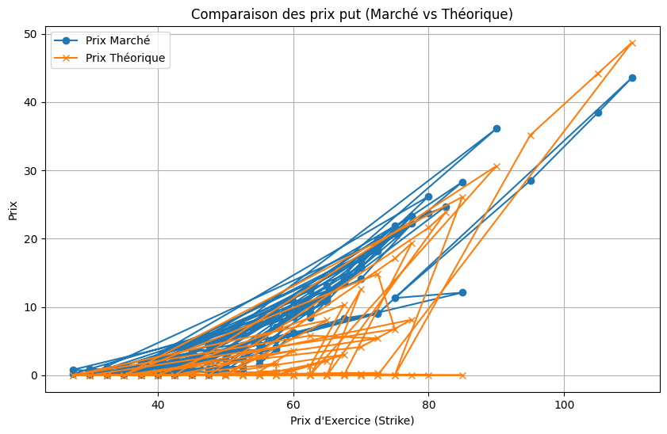

```python
%matplotlib inline
# Calcul des erreurs absolues et relatives
put['Erreur absolue'] = abs(put['Prix théorique'] - put['Price'])
put['Erreur relative (%)'] = 100 * abs(put['Prix théorique'] - put['Price']) / put['Price']

# Visualisation
import matplotlib.pyplot as plt

plt.figure(figsize=(10, 6))
plt.plot(put['Strike price'], put['Price'], label='Prix Marché', marker='o')
plt.plot(put['Strike price'], put['Prix théorique'], label='Prix Théorique', marker='x')
plt.xlabel('Prix d\'Exercice (Strike)')
plt.ylabel('Prix')
plt.title('Comparaison des prix put (Marché vs Théorique)')
plt.legend()
plt.grid()
plt.show()
```

```python
put
```

|  | contractSymbol | lastTradeDate | Strike price | Price | bid | ask | change | percentChange | volume | openInterest | Implied volatility | inTheMoney | contractSize | currency | Maturité | Date | Prix Black-Scholes | Prix théorique | Erreur absolue | Erreur relative (%) |
| --- | --- | --- | --- | --- | --- | --- | --- | --- | --- | --- | --- | --- | --- | --- | --- | --- | --- | --- | --- | --- |
| 0 | TTE250117P00032500 | 2023-06-14 16:00:56 | 32.5 | 1.07 | 0.6 | 1.05 | 0 | 0 | 1.0 | 1 | 1.835938 | False | REGULAR | USD | 0.043836 | 2025-01-17 | 5.474316e-261 | 0.000000e+00 | 1.070000 | 100.000000 |
| 1 | TTE250117P00030000 | 2023-12-04 15:45:03 | 30.0 | 0.18 | 0.0 | 0.00 | 0 | 0 | 20.0 | 50 | 0.500005 | False | REGULAR | USD | 0.043836 | 2025-01-17 | 0.000000e+00 | -3.210580e-15 | 0.180000 | 100.000000 |
| 2 | TTE250117P00037500 | 2023-12-14 20:04:57 | 37.5 | 0.43 | 0.0 | 4.50 | 0 | 0 | 6.0 | 288 | 2.014165 | False | REGULAR | USD | 0.043836 | 2025-01-17 | 7.475597e-169 | 1.605290e-14 | 0.430000 | 100.000000 |
| 3 | TTE250117P00035000 | 2023-12-20 16:42:00 | 35.0 | 0.35 | 0.2 | 3.90 | 0 | 0 | 1.0 | 31 | 2.187505 | False | REGULAR | USD | 0.043836 | 2025-01-17 | 9.553395e-211 | 0.000000e+00 | 0.350000 | 100.000000 |
| 4 | TTE250117P00085000 | 2024-05-13 18:03:11 | 85.0 | 12.10 | 14.6 | 18.70 | 0 | 0 | 4.0 | 4 | 0.000010 | True | REGULAR | USD | 0.043836 | 2025-01-17 | 1.489692e+01 | 2.612067e+01 | 14.020671 | 115.873316 |
| ... | ... | ... | ... | ... | ... | ... | ... | ... | ... | ... | ... | ... | ... | ... | ... | ... | ... | ... | ... | ... |
| 107 | TTE250117P00057500 | 2024-12-30 21:42:56 | 57.5 | 3.84 | 0.0 | 0.00 | 0 | 0 | 7.0 | 0 | 0.000010 | True | REGULAR | USD | 0.043836 | 2025-01-17 | 7.130536e-14 | 1.715509e+00 | 2.124491 | 55.325288 |
| 108 | TTE250516P00057500 | 2024-12-30 21:43:06 | 57.5 | 5.18 | 0.0 | 0.00 | 0 | 0 | 3.0 | 0 | 0.000010 | True | REGULAR | USD | 0.369863 | 2025-05-16 | 9.433797e-165 | 3.593652e-02 | 5.144063 | 99.306245 |
| 109 | TTE270115P00060000 | 2024-12-30 21:43:34 | 60.0 | 10.80 | 0.0 | 0.00 | 0 | 0 | 2.0 | 0 | 0.000010 | True | REGULAR | USD | 2.038356 | 2027-01-15 | 0.000000e+00 | 1.557270e-06 | 10.799998 | 99.999986 |
| 110 | TTE270115P00037500 | 2024-12-30 21:44:50 | 37.5 | 1.80 | 0.0 | 0.00 | 0 | 0 | 4.0 | 0 | 0.062509 | False | REGULAR | USD | 2.038356 | 2027-01-15 | 0.000000e+00 | 2.601471e-07 | 1.800000 | 99.999986 |
| 111 | TTE250815P00055000 | 2024-12-30 21:45:51 | 55.0 | 4.49 | 0.0 | 0.00 | 0 | 0 | 10.0 | 0 | 0.000010 | True | REGULAR | USD | 0.619178 | 2025-08-15 | 1.857601e-289 | 3.407348e-03 | 4.486593 | 99.924113 |

112 rows × 20 columns

Ce tableau présente des données relatives aux options Put calculées à l'aide du modèle de Heston, et il met en lumière des variations intéressantes dans les paramètres observés. Les options affichent des différences marquées dans les prix ask et les volumes échangés, reflétant une variabilité dans la liquidité et l'intérêt des investisseurs pour chaque contrat. Par exemple, certaines options présentent un ask relativement élevé (comme 18,70 USD), ce qui peut indiquer une prime importante associée à la volatilité anticipée ou à une forte demande pour ces contrats. À l’inverse, d'autres options ont un ask de 0, ce qui pourrait signaler un manque total d'intérêt sur le marché pour ces actifs, peut-être en raison de leur éloignement par rapport au prix d'exercice (out of the money). La volatilité implicite varie également considérablement d'une option à l'autre. Certaines options affichent une volatilité extrêmement faible (proche de 0), tandis que d'autres dépassent 2. Cela indique des attentes très différentes concernant la volatilité future des actifs sous-jacents. Les options avec des volatilités très élevées sont souvent associées à des marchés instables ou à des échéances très proches. Cela peut refléter une réaction des investisseurs à des événements imminents ou à des changements importants dans les conditions économiques. Enfin, la maturité des contrats est globalement courte pour une grande partie des options (0,043836 années, soit environ 16 jours), ce qui réduit l’impact du temps sur les prix de ces options. Ces maturités courtes favorisent une plus grande sensibilité des prix théoriques aux variations de la volatilité et aux autres paramètres du modèle, notamment l'évolution des taux d'intérêt ou du prix de l'actif sous-jacent. Cette analyse met en avant les limites pratiques du modèle Heston lorsqu’il est appliqué à des options de maturité courte ou à des options avec des caractéristiques extrêmes, comme des ask très faibles ou nuls.

**Comparaison prix et significativité du modèle erreur relative / erreur absolue**

L’analyse des erreurs absolue et relative met en lumière d’importantes divergences entre les prix calculés par le modèle de Heston et les prix observés sur le marché. Ces écarts, parfois considérables, reflètent les limites du modèle à capturer parfaitement la réalité du comportement des marchés. Par exemple, certaines options présentent des erreurs relatives atteignant ou dépassant 100%, ce qui indique un écart systématique entre les prévisions théoriques et les prix réels. Cela peut être dû à une mauvaise calibration des paramètres du modèle, tels que la volatilité initiale ou la corrélation entre le processus de diffusion de l’actif sous-jacent et celui de la volatilité stochastique. Un exemple particulièrement frappant est celui où l'ask est de 18,70 USD, tandis que l'erreur absolue est de 14,02. Cette divergence massive peut être attribuée à l’incapacité du modèle de Heston à intégrer pleinement certaines dynamiques de marché, comme les sauts brusques dans le prix sous-jacent ou des changements soudains de volatilité non anticipés. De même, pour les options où l'ask est de 0, le modèle estime des prix extrêmement faibles ou proches de zéro, ce qui entraîne des erreurs relatives importantes. Bien que ces options aient peu de valeur marchande, l’ampleur de l’erreur relative reste préoccupante, car elle montre que le modèle est sensible aux variations extrêmes dans les paramètres d’entrée. Ces observations soulignent que, bien que le modèle de Heston offre une approche sophistiquée du pricing en tenant compte de la volatilité stochastique, il reste perfectible. Les erreurs importantes pourraient être corrigées par une meilleure calibration des paramètres, une intégration des événements exogènes ou une approche hybride combinant plusieurs modèles. Enfin, les erreurs constatées sur des options ayant une volatilité implicite très faible ou nulle suggèrent que le modèle peine à refléter la réalité dans des contextes de faible volatilité ou de manque d'intérêt pour ces contrats. Cela pourrait nécessiter une remise en question de certaines hypothèses de base du modèle, notamment dans des contextes de liquidité réduite.

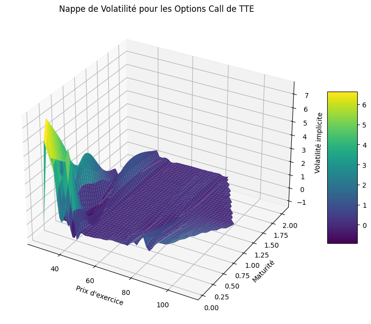

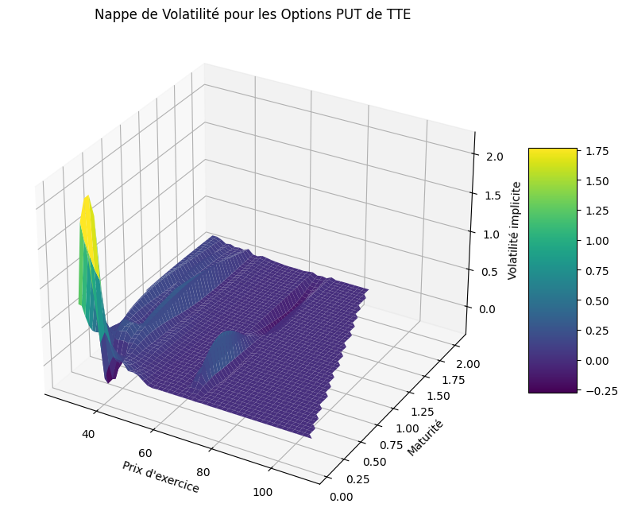

```python
%matplotlib inline
import pandas as pd
import numpy as np
import matplotlib.pyplot as plt
from mpl_toolkits.mplot3d import Axes3D
from scipy.interpolate import griddata

# Charger les données des options depuis le fichier Excel
call_data = pd.read_excel(file, sheet_name='CALL', engine = 'openpyxl')
put_data = pd.read_excel(file, sheet_name='PUT', engine = 'openpyxl')

# Convertir la volatilité implicite en nombre flottant
#call_data['Implied volatility'] = call_data['Implied volatility'].str.rstrip('%').astype('float') / 100
#put_data['Implied volatility'] = put_data['Implied volatility'].str.rstrip('%').astype('float') / 100

# Préparer les données pour le tracé de la surface
# Créer une grille régulière pour le prix d'exercice et la maturité
strike_price_range = np.linspace(call_data['Strike price'].min(), call_data['Strike price'].max(), 50)
maturity_range = np.linspace(call_data['Maturité'].min(), call_data['Maturité'].max(), 50)
strike_price_grid, maturity_grid = np.meshgrid(strike_price_range, maturity_range)

# Interpoler la volatilité implicite sur cette grille
implied_volatility_grid = griddata(
    (call_data['Strike price'], call_data['Maturité']),
    call_data['Implied volatility'],
    (strike_price_grid, maturity_grid),
    method='cubic'
)

# Créer la figure pour le tracé
fig = plt.figure(figsize=(10, 8))
ax = fig.add_subplot(111, projection='3d')

# Tracer la surface de volatilité
surf = ax.plot_surface(strike_price_grid, maturity_grid, implied_volatility_grid, cmap='viridis', edgecolor='none')

# Ajouter une barre de couleur pour la légende
fig.colorbar(surf, shrink=0.5, aspect=5)

# Ajouter les étiquettes et le titre
ax.set_xlabel('Prix d\'exercice')
ax.set_ylabel('Maturité')
ax.set_zlabel('Volatilité implicite')
ax.set_title('Nappe de Volatilité pour les Options Call de TTE')

plt.show()

# Répéter le processus pour les options PUT

# Note: la maturité maximale pour les PUT devrait probablement être put_data['MATURITE'].max()
# et non call_data['MATURITE'].max(), à moins que ce ne soit intentionnel de les synchroniser.
maturity_range = np.linspace(put_data['Maturité'].min(), put_data['Maturité'].max(), 50)
strike_price_grid, maturity_grid = np.meshgrid(strike_price_range, maturity_range)

# Interpoler la volatilité implicite sur cette grille
implied_volatility_grid = griddata(
    (put_data['Strike price'], put_data['Maturité']),
    put_data['Implied volatility'],
    (strike_price_grid, maturity_grid),
    method='cubic'
)

# Créer la figure pour le tracé
fig = plt.figure(figsize=(10, 8))
ax = fig.add_subplot(111, projection='3d')

# Tracer la surface de volatilité
surf = ax.plot_surface(strike_price_grid, maturity_grid, implied_volatility_grid, cmap='viridis', edgecolor='none')

# Ajouter une barre de couleur pour la légende
fig.colorbar(surf, shrink=0.5, aspect=5)

# Ajouter les étiquettes et le titre
ax.set_xlabel('Prix d\'exercice')
ax.set_ylabel('Maturité')
ax.set_zlabel('Volatilité implicite')
ax.set_title('Nappe de Volatilité pour les Options PUT de TTE')

# Afficher le graphique
plt.show()
```